# MACROECONOMIA INTERTEMPORAL I - 2019

# Capítulo 1 - *Jupyter* e *Julia*

# Preliminar. Não citar. Comentários bem-vindos.

## Introdução

Neste capítulo veremos como preparar nosso ambiente de trabalho para o curso.

Utilizaremos no curso os *notebooks* [Jupyter](https://jupyter.org/). Os *notebooks* fornecem um ambiente de programação prático e poderoso. Permitem programação matemática, edição de texto, análise de dados, utilização de imagens... Mas a melhor maneira de entender os *notebooks* é utilizando-os.

## O ambiente Julia

Utilizaremos os *notebooks Jupyter* com a linguagem com a linguagem [Julia](https://julialang.org/), para os quais há três alternativas gratuitas: *Julia*, *JuliaBox* e *JuliaPro* - preste atenção nas diferenças. Ao contrário dos outros dois, o *JuliaBox* roda *online* e não precisa de instalação local. Se você tem acesso fácil e confiável à rede, essa é, provavelmente, a melhor opção para começar.

Vejamos como instalar as diferentes versões.

### JuliaBox

(i) Acesse o [Julia computing](https://juliacomputing.com/).

(ii) Clique no *JuliaBox* e siga as instruções para criação de conta.

(iii) Quando estiver rodando, você deverá ver essa tela:

[figure not shown]

Inicie o programa e você deverá ver uma tela semelhante a essa:

[figure not shown]

Sua tela será um pouco diferente da minha, pois eu gravei diversos *notebooks* anteriormente.

Essa é a página principal do *notebook Jupyter*. Mais adiante veremos como utilizar o programa. Antes disso, vejamos como obter o *notebook Jupyter* com o *Julia* ou o *JuliaPro*.

Note três coisas nessa tela, a serem discutidas adiante. (i) O seu *login* no canto superior direito. (ii) A presença da aba *NBextensions*. (iii) O botão *New*.

### Julia

Acesse o [Julia](https://julialang.org/) e faça o *download* da versão mais recente do instalador do *Julia*. Uma vez instalado, abra o programa e você obterá essa tela:

[figure not shown]

Execute os seguintes comandos - preste atenção a maiúsculas, aspas etc:

```
using Pkg
Pkg.add("IJulia")
using IJulia
notebook()
```

[figure not shown]

Depois que o programa acabar de executar, você obterá no seu *browser* a mesma tela inicial do *notebook Jupyter* vista anteriormente.

Note: você só precisa adicionar o *IJulia* (`using Pkg` e `Pkg.add("IJulia")`) uma vez a cada seção. Mas cada vez que iniciar uma nova seção do *Julia* precisará executar `using IJulia` e `notebook()`.

### JuliaPro

O *JuliaPro* pode ser acessado na mesma página do *JuliaBox* ao qual oferece uma alternativa *offline*, além de vários outros recursos. Infelizmente, no momento em que escrevo, problemas de compatibilidade atrapalham a utilização dos *notebooks Jupyter*. Por isso, deixarei de lado o *JuliaPro*, por ora.

## Notebook Jupyter

Com o *notebook Jupyter* instalado, vejamos como começar a utilizá-lo. (Vou me referir ao *JuliaBox*, mas a utlização no *Julia* é semelhante.)

### Criar um *notebook*

Na página principal do *JuliaBox*, clique em `New` e escolha a versão mais recente do *Julia* (atualmente 1.0.3). Você obterá a seguinte tela:

[figure not shown]

Digite algo como *1+1* na célula verde e tecle `Shift+Enter` ou clique em `Run`. Você obterá:

[figure not shown]

Como você vê, o resultado aparece abaixo dos comandos e uma nova célula é criada.

A célula que você acabou de utilizar é uma célula de código (*Code*) - veja no alto da tela. Esse tipo de célula serve para executar operações matemáticas e programas. Para digitar texto, clique na seta ao lado de *Code* e selecione `Markdown`. (Markdown é uma linguagem para ediçãode texto.) Digite um texto e clique `Shift+Enter`. Você obterá:

[figure not shown]

Clique duas vezes em uma célula para tornar a abrí-la, se quiser continuar digitando.

### Salvar um *notebook*

Escolha um nome para seu arquivo: `File-Rename`. Salve seu *notebook* no ícone característico. Você terá salvo um arquivo no formato *nome.ipynb*. Esse é o formato para salvar os arquivos executáveis.

Quando encerrar, após salvar, feche o *notebook*: `File-Close and Halt`. Salve seu trabalho períodicamente. Uma desvantagem do *JuliaBox* é que cada seção gratuita só dura 90 minutos. Após o término, é necessário iniciar uma nova.

Para poupar espaço na memória, antes de salvar o *notebook*: `Kernel` e `Restart & Clear Ouptut`. Ao abrir um *notebook* gravado desa forma: `Cell-Run All` para exibir todo o conteúdo ou execute cada célula de uma vez.

### Salvar em outros formatos

Você pode salvar seu arquivo em vários formatos. Por exemplo, este arquivo está disponível na *Conexão* em dois formatos: *Cp01.html* (navegável) e *Cp01.ipynb* (executável).

O formato padrão é o do *notebook* (*nome.ipynb*). Para salvar (e baixar) em outro formato: `File-Download as` e escolha o formato desejado.

### Carregar um arquivo

Você pode fazer o *upload* de diversos arquivos, inclusive *notebooks*, para a sua página do *Jupyter*. Para isso, vá para a página principal, clique em `upload` no canto superior direito, selecione o arquivo e faça o *upload*. Você precisará disso para carregar os *notebooks* disponíveis na *Conexão UFF*.

### Numeração das seções

As seções dos *notebooks* do curso são numeradas. Se a numeração não aparecer quando você abrir o *notebook*, faça o seguinte.

Caso a aba `nbextensions config` esteja visível na página principal.

(i) Clique nela.

(ii) Clique `Table of Contents (2)`.

(iii) Clique na aba `Files`e abra seu *notebook*.

[figure not shown]

Caso a aba `nbextensions config` não esteja visível.

(i) Clique `Edit-nbextensions config`.

(ii) Na nova tela, clique `Table of Contents (2)`.

(iii) Volte para o *notebook* e clique no botão `refresh` ↻.

Por algum motivo, a numeração não aparece na versão *html*.

#### Sub-seções

Note que há vários níveis de seções e sub-seções. A numeração automática é feita com o símbolo $#$. O número de símbolos indica o nível da seção. Digite o texto abaixo e execute:

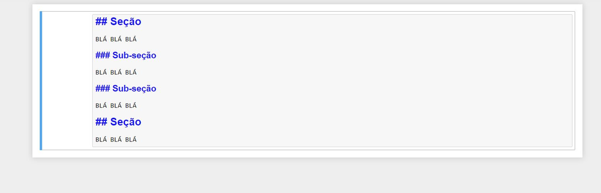

O resultado é:

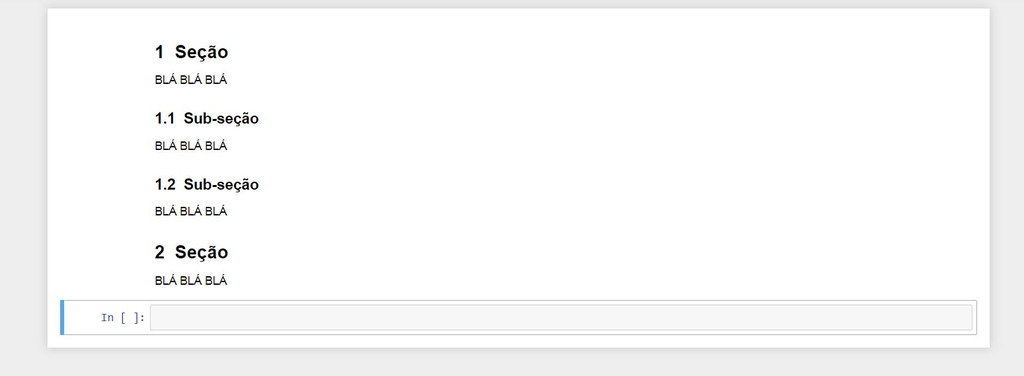

### Encerrar a seção

Após salvar e fechar o *notebook* (`Save-Close and Halt`), encerre a seção do *JuliaBox*. Na página principal, clique no seu *login* e escolha `Logout`.

Antes de iniciar uma nova seção, talvez seja necessário clicar no botão `refresh` ↻.

## Resumo

Abra seu *notebook*.

Escolha *Code* ou *Markdown* no tipo de célua. Digite os comandos ou texto. Execute a célula com `Shift+Enter`.

Salve seu trabalho periodicamente.

Encerre o *notebook*: `Save-Close and Halt`.

Encerre a seção: `Logout`.

## Conclusão

Os modelos macroeconômicos atuais raramente possuem soluções analíticas - com lápis e papel - e precisam ser resolvidos numericamente, no computador. O domínio dessas técnicas exige um investimento inicial expressivo, mas elas são indipensáveis para a atividade profissional. O início pode ser um pouco penoso, mas o investimento vale a pena.

## Exercícios

**Exercício 1**

(i) Crie um *notebook*.

(ii) Execute algumas operações aritméticas simples. Digite algum texto.

(iii) Crie e sub-seções com numeração automática.

(iv) Salve e baixe nos formatos *ipynp* e *html*.

(v) Faça o *upload* desses arquivos.

♦

**Exercício 2**

(i) Crie as [matrizes](https://lectures.quantecon.org/jl/fundamental_types.html):

$A = \begin{bmatrix} 1 & 2 \\ 3 & 4 \\ \end{bmatrix} \;\;\;\; B = \begin{bmatrix} 5 & 6 \\ 7 & 8 \\ \end{bmatrix} $

(ii) Compute: $A'$ , $A^{-1}$ , $A*B$ , $A.*B$ (multiplicação célula por célula: $a_{ij}*b_{ij}$).

(iii) Crie um vetor igual à primeira coluna de A; e outro igual à segunda linha.

(iv) Some as linhas de A.

♣

**Exercício 3**

Escreva um [loop](https://lectures.quantecon.org/jl/julia_by_example.html) para somar os números inteiros de 1 a 5. Exiba o resultado.

♠

## Referências e leitura adicional

Há inúmeros tutoriais sobre o *Julia* na rede. Por exemplo: [Julialang](https://docs.julialang.org/en/v0.6.2/index.html); [JuliaBox](https://docs.juliabox.com/); [Learning Julia](https://julialang.org/learning/); [cluster](https://clusterdata.nl/bericht/news-item/julia-tutorial-get-started-with-the-julia-language/). [QuantEcon](https://quantecon.org/) apresenta tutoriais do *Julia* voltados para economistas; veja os exemplos para [graduação](https://lectures.quantecon.org/jl/index_undergrad.html).

Note que há diferenças entre as versões *1.xx* do *Julia* e as anteriores. Tutoriais antigos podem apresentar problemas de compatibilidade com as versões mais recentes.